# Tutorial 13 - Final project preparation

Author: Matthew J. Crossley

Last update: 29 March, 2026

```r
# load libraries

library(data.table)
library(ggplot2)

# clean work space

rm(list = ls())

# init colorscheme

COL <- c("#2271B2", "#E69F00", "#D55E00")
names(COL) <- c("blue", "orange", "red")
theme_set(
  theme_minimal(base_size = 13) +
    theme(
      panel.grid.minor = element_blank(),
      strip.text = element_text(face = "bold"),
      legend.position = "bottom"
    )
)
update_geom_defaults("point", list(size = 2))
update_geom_defaults("line", list(linewidth = 0.8))
```

## Overview

Welcome to the final tutorial for COGS2020. There is **no new statistical content** today. Instead, this session is entirely dedicated to helping you finalise your project, practice your oral presentation, and make sure everything works before you hit record.

By the end of this tutorial you should:

- Know the expected structure of your video presentation.
- Have run through your full presentation at least once with a timer.
- Have received peer feedback on a short excerpt of your presentation.
- Have completed the final project checklist.

Your final project requires you to record a video (~8–10 minutes, maximum 12 minutes) in which you demonstrate your analysis in a **live R session**. You will also submit your R code files. The assessment covers data loading and wrangling, at least two `ggplot2` plots, at least one t-test, at least one ANOVA or regression, and a discussion of interpretation and limitations.

**Your assigned dataset is determined by the last digit of your student ID:**

| Last digit (`last_digit %% 3`) | Dataset |
| --- | --- |
| `== 0` | https://github.com/crossley/cogs2020/tree/main/final_project_data/cat_learn_switch |
| `== 1` | https://github.com/crossley/cogs2020/tree/main/final_project_data/cat_learn_auto |
| `== 2` | https://github.com/crossley/cogs2020/tree/main/final_project_data/cat_learn_unlearn |

## Part 1 — Presentation structure

Use the following structure for your recording. Stick to these time targets so you don’t run over 12 minutes.

### Recommended timing

| Section | Content | Time |
| --- | --- | --- |
| 1 | Dataset and Research Question | 1–2 minutes |
| 2 | Data Wrangling and Visualisation | 2–3 minutes |
| 3 | Statistical Analysis | 3–4 minutes |
| 4 | Interpretation and Limitations | 2–3 minutes |

### What each section should cover

**Section 1 — Dataset and Research Question (1–2 min)**  
Briefly describe the dataset: where it came from, what was measured, and who the participants were. State your research question clearly. What are you trying to find out? Which variables are you focusing on?

**Section 2 — Data Wrangling and Visualisation (2–3 min)**  
Show how you loaded the data and prepared it for analysis. Walk through any cleaning steps (renaming columns, filtering, reshaping). Then present your plots — explain what each one shows and what you conclude from it.

**Section 3 — Statistical Analysis (3–4 min)**  
Run your tests or models live. For each one, briefly explain why you chose it (e.g., “I used a paired t-test because each participant was measured twice under different conditions”). Show the output and narrate the key numbers.

**Section 4 — Interpretation and Limitations (2–3 min)**  
Explain what your results mean in plain language — not just the p-value, but what the finding suggests about the cognitive phenomenon under study. Then discuss at least one assumption you checked (or should check) for each test, and identify at least one limitation of the study or your analysis.

### Project checklist

Use this as a go / no-go list before you start recording.

- Code loads and runs without error from top to bottom
- At least two `ggplot2` plots with clear axis labels, a title, and a legend (where applicable)
- At least one t-test, with a verbal interpretation of the result
- At least one ANOVA or regression, with a verbal interpretation of the result
- At least one assumption discussed for each statistical test
- A brief discussion of limitations
- Video is ≤ 12 minutes in total
- Your face is visible throughout the recording
- Code is **executed live** — not just scrolled through
- R code files are submitted alongside the video

## Part 2 — Common pitfalls

These are the mistakes that come up most often. Check each one now, before you record.

### 1. Code won’t run in a fresh session

The most common issue: your script runs fine in a session you’ve been using for hours, but fails the moment you restart R — because you have objects in memory that aren’t created by your script.

**Fix:** Restart R and run everything from scratch before recording.

- `Ctrl + Shift + F10` — restarts R (clears all objects from memory)
- `Ctrl + Shift + Enter` — runs the entire script from top to bottom

Do this now. If anything breaks, fix it before you record.

### 2. Plots with missing labels

An unlabelled plot is hard to interpret and will cost marks. Compare these two versions:

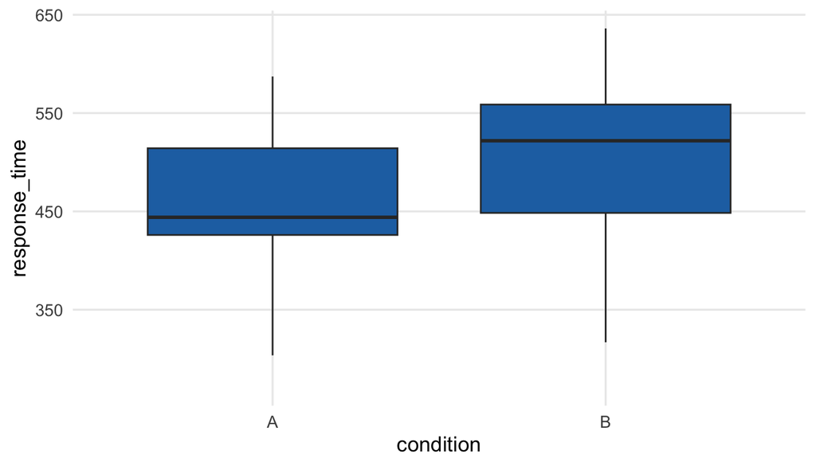

```r
# Simulated data for illustration
set.seed(42)
dt <- data.table(
  condition = rep(c("A", "B"), each = 30),
  response_time = c(rnorm(30, mean = 450, sd = 60),
                    rnorm(30, mean = 510, sd = 80))
)

# Without labels — not acceptable
ggplot(dt, aes(x = condition, y = response_time)) +
  geom_boxplot(fill = COL[1], outlier.shape = NA)
```

[figure not shown]

```r
# With labels — what your plots should look like
ggplot(dt, aes(x = condition, y = response_time, fill = condition)) +
  geom_boxplot(outlier.shape = NA) +
  scale_fill_manual(values = COL) +
  labs(
    title = "Response time by condition",
    x = "Condition",
    y = "Response time (ms)",
    fill = "Condition"
  ) +
  theme(legend.position = "none")
```

Every plot must have a title and clear axis labels. Add a legend whenever colour or fill encodes a variable.

### 3. Showing output without interpreting it

Printing a result and moving on is not enough. You must explain what it means.

```r
# Example t-test
result <- t.test(response_time ~ condition, data = dt)
result
```

```
##
##  Welch Two Sample t-test
##
## data:  response_time by condition
## t = -2.2397, df = 57.32, p-value = 0.029
## alternative hypothesis: true difference in means between group A and group B is not equal to 0
## 95 percent confidence interval:
##  -87.371920  -4.892299
## sample estimates:
## mean in group A mean in group B
##        454.1152        500.2473
```

### 4. Confusing standard deviation and standard error

These come up in summary tables and plot error bars. Keep them straight:

- **Standard deviation (SD):** describes the spread of individual observations around the mean.
- **Standard error (SE):** describes how precisely the mean is estimated; SE = SD / √n.

If you are plotting variability in the *data*, use SD. If you are plotting uncertainty in a *mean* estimate, use SE. Either is acceptable for this project — just be consistent and label your error bars clearly.

### 5. Running over time

A recording that exceeds 12 minutes will be penalised. The most common cause is spending too long on wrangling or running through too many plots.

**Timing template:**

| Section | Target | Your time (fill in) |
| --- | --- | --- |
| Dataset and research question | ≤ 2 min |  |
| Wrangling and visualisation | ≤ 3 min |  |
| Statistical analysis | ≤ 4 min |  |
| Interpretation and limitations | ≤ 3 min |  |
| **Total** | **≤ 12 min** |  |

Run through this with a real timer today (see Part 3).

### 6. Scrolling through code instead of running it

The assessment requires you to **execute code live** and show the output. Scrolling through a pre-written script without running it does not satisfy this requirement.

During your recording: place your cursor at the top of your script, restart R, then run each chunk or section using `Ctrl + Enter` (run current line / selection) or `Ctrl + Shift + Enter` (run entire script). The output must be visible on screen.

## Part 3 — Timing walkthrough (in-class activity)

**Your task for the next 20 minutes:** open your analysis script, set a timer, and run through your entire presentation as if it were the real recording. Follow the structure in Part 1. Narrate out loud — don’t just run code silently.

## Part 4 — Peer review (in-class activity)

**Work with a partner.** One person delivers the first 3 minutes of their presentation (Sections 1 and the start of Section 2) while the other listens. After 3 minutes, stop. The listener gives feedback on:

- Was the research question stated clearly? Could you describe it back in one sentence?
- Was it clear what each piece of code was doing, or did it feel like unexplained steps?
- Was any statistical output interpreted, or was it just shown on screen?

Then swap roles.

Use this feedback to refine the language you use when you record. You don’t need to change your analysis — just tighten up how you describe it.

## Part 5 — Final checklist

Complete this individually before you start recording. Be honest with yourself — every unchecked box is something to fix today while you still have help available.

[output not shown]

## A final note

You have covered a lot of ground this semester - from loading data in R for the first time, through visualisation, t-tests, ANOVA, and regression. The final project is your opportunity to bring all of that together in a single coherent analysis.

The goal is not to produce perfect results. It is to show that you understand what you did and why. Running code live, narrating what is happening, and explaining your results honestly — even when they are messy or non-significant — is far more impressive than presenting polished pre-generated output that you can’t speak to.

Statistically significant results are **not required**. A null result, clearly explained and thoughtfully discussed, is just as valid as a significant one. What is assessed is your reasoning and your ability to communicate it.

The final step is to present that reasoning clearly and confidently.